# Importation des données nettoyées

```python
import pandas as pd
```

```python
dataPropre = pd.read_csv(
    'Desktop/Openclassrooms/P9_Shibin_YANG/Data_Propre_P9.csv')
```

```python
dataPropre
```

|  | Zone | Population | Dispo intérieure poulet | Exportations poulet | Importations poulet | Production poulet | Consommation poulet | Part importation poulet(%) | Part consommation poulet(%) | Stabilité politique | PIB par habitant(USD) |
| --- | --- | --- | --- | --- | --- | --- | --- | --- | --- | --- | --- |
| 0 | Afghanistan | 36296113 | 57000.0 | NaN | 29000.0 | 28000.0 | 55000.0 | 0.64 | 0.42 | -2.80 | 513.09 |
| 1 | Afrique du Sud | 57009756 | 2118000.0 | 63000.0 | 514000.0 | 1667000.0 | 2035000.0 | 5.70 | 6.41 | -0.28 | 6121.88 |
| 2 | Albanie | 2884169 | 47000.0 | 0.0 | 38000.0 | 13000.0 | 47000.0 | 4.30 | 1.29 | 0.38 | 4514.20 |
| 3 | Algérie | 41389189 | 277000.0 | 0.0 | 2000.0 | 275000.0 | 264000.0 | 0.01 | 0.80 | -0.92 | 4109.70 |
| 4 | Allemagne | 82658409 | 1739000.0 | 646000.0 | 842000.0 | 1514000.0 | 1609000.0 | 1.27 | 2.06 | 0.59 | 44552.06 |
| ... | ... | ... | ... | ... | ... | ... | ... | ... | ... | ... | ... |
| 163 | Venezuela (République bolivarienne du) | 29402484 | 626000.0 | 0.0 | 25000.0 | 600000.0 | 596000.0 | 0.54 | 3.80 | -1.25 | 8429.07 |
| 164 | Viet Nam | 94600648 | 1206000.0 | 1000.0 | 291000.0 | 918000.0 | 1166000.0 | 1.14 | 1.73 | 0.29 | 2365.52 |
| 165 | Yémen | 27834819 | 246000.0 | 0.0 | 78000.0 | 168000.0 | 237000.0 | 1.27 | 2.82 | -2.94 | 745.09 |
| 166 | Zambie | 16853599 | 60000.0 | 1000.0 | 12000.0 | 49000.0 | 58000.0 | 2.28 | 0.97 | 0.15 | 1534.87 |
| 167 | Zimbabwe | 14236595 | 76000.0 | NaN | 6000.0 | 69000.0 | 67000.0 | 0.56 | 1.39 | -0.71 | 1548.19 |

168 rows × 11 columns

```python
dataPropre.info()
```

```
<class 'pandas.core.frame.DataFrame'>
RangeIndex: 168 entries, 0 to 167
Data columns (total 11 columns):
 #   Column                       Non-Null Count  Dtype
---  ------                       --------------  -----
 0   Zone                         168 non-null    object
 1   Population                   168 non-null    int64
 2   Dispo intérieure poulet      166 non-null    float64
 3   Exportations poulet          132 non-null    float64
 4   Importations poulet          166 non-null    float64
 5   Production poulet            164 non-null    float64
 6   Consommation poulet          166 non-null    float64
 7   Part importation poulet(%)   166 non-null    float64
 8   Part consommation poulet(%)  166 non-null    float64
 9   Stabilité politique          168 non-null    float64
 10  PIB par habitant(USD)        168 non-null    float64
dtypes: float64(9), int64(1), object(1)
memory usage: 14.6+ KB
```

# Analyse en composantes principales

```python
import matplotlib.pyplot as plt
from matplotlib.collections import LineCollection

# Définition de la fonction pour le graphique Cercle de corrélation
def display_circles(pcs, n_comp, pca, axis_ranks, labels=None, label_rotation=0, lims=None):
    for d1, d2 in axis_ranks:  # On affiche les 3 premiers plans factoriels, donc les 6 premières composantes
        if d2 < n_comp:

            # initialisation de la figure
            fig, ax = plt.subplots(figsize=(10, 10))

            # détermination des limites du graphique
            if lims is not None:
                xmin, xmax, ymin, ymax = lims
            elif pcs.shape[1] < 30:
                xmin, xmax, ymin, ymax = -1, 1, -1, 1
            else:
                xmin, xmax, ymin, ymax = min(pcs[d1, :]), max(
                    pcs[d1, :]), min(pcs[d2, :]), max(pcs[d2, :])

            # affichage des flèches
            # s'il y a plus de 30 flèches, on n'affiche pas le triangle à leur extrémité
            if pcs.shape[1] < 30:
                plt.quiver(np.zeros(pcs.shape[1]), np.zeros(pcs.shape[1]),
                           pcs[d1, :], pcs[d2, :],
                           angles='xy', scale_units='xy', scale=1, color="grey")
            else:
                lines = [[[0, 0], [x, y]] for x, y in pcs[[d1, d2]].T]
                ax.add_collection(LineCollection(
                    lines, axes=ax, alpha=.1, color='black'))

            # affichage des noms des variables
            if labels is not None:
                for i, (x, y) in enumerate(pcs[[d1, d2]].T):
                    if x >= xmin and x <= xmax and y >= ymin and y <= ymax:
                        plt.text(x, y, labels[i], fontsize='14', ha='center',
                                 va='center', rotation=label_rotation, color="blue", alpha=0.5)

            # affichage du cercle
            circle = plt.Circle((0, 0), 1, facecolor='none', edgecolor='b')
            plt.gca().add_artist(circle)

            # définition des limites du graphique
            plt.xlim(xmin, xmax)
            plt.ylim(ymin, ymax)

            # affichage des lignes horizontales et verticales
            plt.plot([-1, 1], [0, 0], color='grey', ls='--')
            plt.plot([0, 0], [-1, 1], color='grey', ls='--')

            # nom des axes, avec le pourcentage d'inertie expliqué
            plt.xlabel('F{} ({}%)'.format(
                d1+1, round(100*pca.explained_variance_ratio_[d1], 1)))
            plt.ylabel('F{} ({}%)'.format(
                d2+1, round(100*pca.explained_variance_ratio_[d2], 1)))

            plt.title("Cercle des corrélations (F{} et F{})".format(d1+1, d2+1))
            plt.show(block=False)


# Définition de la fonction pour le graphique Projection des individus sur les plans factoriels
def display_factorial_planes(X_projected, n_comp, pca, axis_ranks, labels=None, alpha=1, illustrative_var=None):
    for d1, d2 in axis_ranks:
        if d2 < n_comp:

            # initialisation de la figure
            fig = plt.figure(figsize=(10, 10))

            # affichage des points
            if illustrative_var is None:
                plt.scatter(X_projected[:, d1],
                            X_projected[:, d2], alpha=alpha)
            else:
                illustrative_var = np.array(illustrative_var)
                for value in np.unique(illustrative_var):
                    selected = np.where(illustrative_var == value)
                    plt.scatter(
                        X_projected[selected, d1], X_projected[selected, d2], alpha=alpha, label=value)
                plt.legend()

            # affichage des labels des points
            if labels is not None:
                for i, (x, y) in enumerate(X_projected[:, [d1, d2]]):
                    plt.text(x, y, labels[i],
                             fontsize='14', ha='center', va='center')

            # détermination des limites du graphique
            boundary = np.max(np.abs(X_projected[:, [d1, d2]])) * 1.1
            plt.xlim([-boundary, boundary])
            plt.ylim([-boundary, boundary])

            # affichage des lignes horizontales et verticales
            plt.plot([-100, 100], [0, 0], color='grey', ls='--')
            plt.plot([0, 0], [-100, 100], color='grey', ls='--')

            # nom des axes, avec le pourcentage d'inertie expliqué
            plt.xlabel('F{} ({}%)'.format(
                d1+1, round(100*pca.explained_variance_ratio_[d1], 1)))
            plt.ylabel('F{} ({}%)'.format(
                d2+1, round(100*pca.explained_variance_ratio_[d2], 1)))

            plt.title(
                "Projection des individus (sur F{} et F{})".format(d1+1, d2+1))
            plt.show(block=False)


# Définition de la fonction pour le graphique Éboulis des valeurs propres
def display_scree_plot(pca):
    scree = pca.explained_variance_ratio_*100
    plt.bar(np.arange(len(scree))+1, scree)
    plt.plot(np.arange(len(scree))+1, scree.cumsum(), c="red", marker='o')
    plt.xlabel("rang de l'axe d'inertie")
    plt.ylabel("pourcentage d'inertie(%)")
    plt.title("Éboulis des valeurs propres")
    plt.show(block=False)
```

```python
import numpy as np
from sklearn import decomposition, preprocessing
```

## Préparation des données pour l'ACP

```python
# Indexation par la colonne Zone
data = dataPropre.set_index('Zone')
data
```

| Zone | Population | Dispo intérieure poulet | Exportations poulet | Importations poulet | Production poulet | Consommation poulet | Part importation poulet(%) | Part consommation poulet(%) | Stabilité politique | PIB par habitant(USD) |
| --- | --- | --- | --- | --- | --- | --- | --- | --- | --- | --- |
| Afghanistan | 36296113 | 57000.0 | NaN | 29000.0 | 28000.0 | 55000.0 | 0.64 | 0.42 | -2.80 | 513.09 |
| Afrique du Sud | 57009756 | 2118000.0 | 63000.0 | 514000.0 | 1667000.0 | 2035000.0 | 5.70 | 6.41 | -0.28 | 6121.88 |
| Albanie | 2884169 | 47000.0 | 0.0 | 38000.0 | 13000.0 | 47000.0 | 4.30 | 1.29 | 0.38 | 4514.20 |
| Algérie | 41389189 | 277000.0 | 0.0 | 2000.0 | 275000.0 | 264000.0 | 0.01 | 0.80 | -0.92 | 4109.70 |
| Allemagne | 82658409 | 1739000.0 | 646000.0 | 842000.0 | 1514000.0 | 1609000.0 | 1.27 | 2.06 | 0.59 | 44552.06 |
| ... | ... | ... | ... | ... | ... | ... | ... | ... | ... | ... |
| Venezuela (République bolivarienne du) | 29402484 | 626000.0 | 0.0 | 25000.0 | 600000.0 | 596000.0 | 0.54 | 3.80 | -1.25 | 8429.07 |
| Viet Nam | 94600648 | 1206000.0 | 1000.0 | 291000.0 | 918000.0 | 1166000.0 | 1.14 | 1.73 | 0.29 | 2365.52 |
| Yémen | 27834819 | 246000.0 | 0.0 | 78000.0 | 168000.0 | 237000.0 | 1.27 | 2.82 | -2.94 | 745.09 |
| Zambie | 16853599 | 60000.0 | 1000.0 | 12000.0 | 49000.0 | 58000.0 | 2.28 | 0.97 | 0.15 | 1534.87 |
| Zimbabwe | 14236595 | 76000.0 | NaN | 6000.0 | 69000.0 | 67000.0 | 0.56 | 1.39 | -0.71 | 1548.19 |

168 rows × 10 columns

```python
# Préparation des données pour l'ACP
data = data.fillna(0)
X = data.values
names = data.index
features = data.columns

X.shape
```

```
(168, 10)
```

```python
# Centrage et Réduction
std_scale = preprocessing.StandardScaler().fit(X)
X_scaled = std_scale.transform(X)
X_scaled
```

```
array([[ 0.0092901 , -0.30441039, -0.22311413, ..., -0.99934374,
        -3.04231679, -0.68875132],
       [ 0.19485734,  0.88868344, -0.0863063 , ...,  1.41735198,
        -0.23463654, -0.39928694],
       [-0.29003736, -0.31019929, -0.22311413, ..., -0.64833785,
         0.50070828, -0.48225779],
       ...,
       [-0.06651206, -0.19500004, -0.22311413, ..., -0.03105163,
        -3.19829902, -0.67677802],
       [-0.16488948, -0.30267371, -0.22094258, ..., -0.77744346,
         0.24445175, -0.63601822],
       [-0.18833442, -0.29341146, -0.22311413, ..., -0.60799234,
        -0.71372484, -0.63533078]])
```

## Calcul des composantes principales

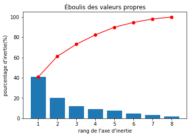

```python
# Nombre de composants souhaités
n_comp = 8

# Calcul des composantes principales
pca = decomposition.PCA(n_components=n_comp)
pca.fit(X_scaled)

display_scree_plot(pca)
plt.show()
```

```python
# Variance expliquée
pca.explained_variance_
```

```
array([4.09501194, 2.05093637, 1.20583791, 0.93111671, 0.75668849,
       0.4769169 , 0.34211798, 0.19869624])
```

```python
# Proportion de variance expliquée
pca.explained_variance_ratio_
```

```
array([0.40706369, 0.20387284, 0.11986603, 0.09255743, 0.07521844,
       0.04740781, 0.03400816, 0.01975135])
```

```python
# Cumul de variance expliqué
pca.explained_variance_ratio_.sum()
```

```
0.9997457520423849
```

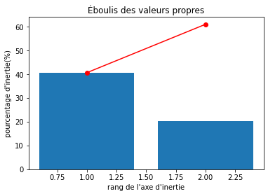

```python
# Choix du nombre des composantes principales
n_comp = 2
pca = decomposition.PCA(n_components=n_comp)
pca.fit(X_scaled)

display_scree_plot(pca)
plt.show()
```

## Cercle des corrélations

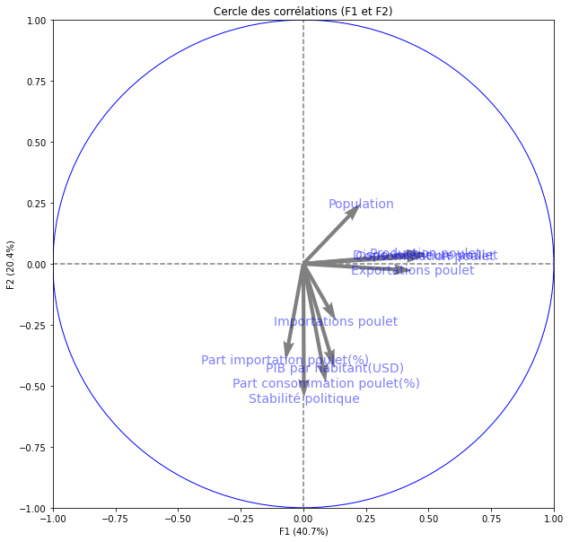

```python
# Cercle des corrélations
pcs = pca.components_
display_circles(pcs, n_comp, pca, [(0, 1)], labels=np.array(features))

plt.show()
```

On peut déjà voir les variables corrélées sur la dimension 1, et anti corrélée sur la dimension 2. Je ne vais pas entrer dans le détail, car j’ai trouvé des outliers que je vais parler juste après, qui va influencer l’analyse.

## Projection des individus

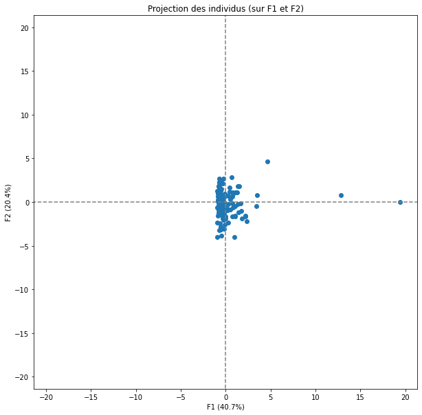

```python
# Projection des individus sur F1 et F2
X_projected = pca.transform(X_scaled)
display_factorial_planes(X_projected, n_comp, pca, [(0, 1)])

plt.show()
```

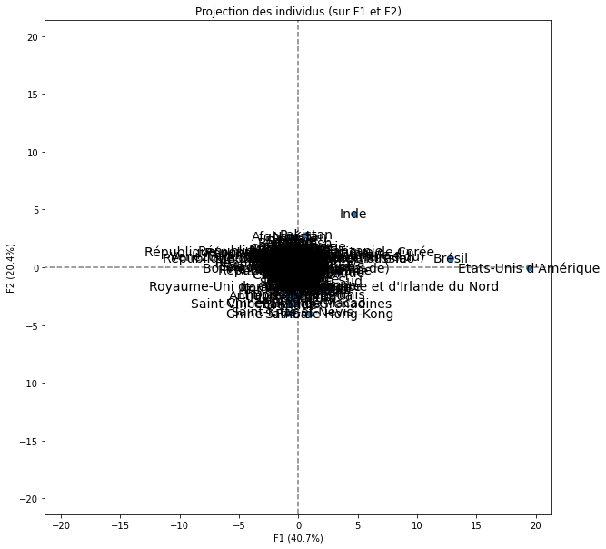

```python
# Projection des individus sur F1 et F2 avec labels pour idendifier les outliers
X_projected = pca.transform(X_scaled)
display_factorial_planes(X_projected, n_comp, pca, [
                         (0, 1)], labels=np.array(names))

plt.show()
```

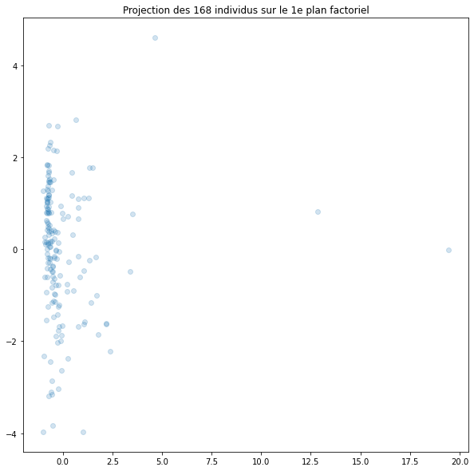

```python
# Comme on peut voir des outiliers, pour mieur voir,
# on faire une projection des individus sur le premier plan factoriel

X_projected = pca.transform(X_scaled)
fig = plt.figure(figsize=(10, 10))
plt.scatter(X_projected[:, 0], X_projected[:, 1], alpha=0.2)
plt.title("Projection des {} individus sur le 1e plan factoriel".format(
    X_projected.shape[0]))
plt.show(block=False)
```

## Outliers

Là, on peut observer et identifier qu'il y a trois individus étant loins de groupe, cela va biaiser l'analyse. Donc, on va ensuit faire une analyse sans ces trois pays, l'Inde, Brésil et États-unis.

## Préparation des données après exclure les outliers

```python
# Nouvelles données après exclure les outliers
data1 = data.drop(index=["Brésil", "Inde", "États-Unis d'Amérique"])
data1
```

| Zone | Population | Dispo intérieure poulet | Exportations poulet | Importations poulet | Production poulet | Consommation poulet | Part importation poulet(%) | Part consommation poulet(%) | Stabilité politique | PIB par habitant(USD) |
| --- | --- | --- | --- | --- | --- | --- | --- | --- | --- | --- |
| Afghanistan | 36296113 | 57000.0 | 0.0 | 29000.0 | 28000.0 | 55000.0 | 0.64 | 0.42 | -2.80 | 513.09 |
| Afrique du Sud | 57009756 | 2118000.0 | 63000.0 | 514000.0 | 1667000.0 | 2035000.0 | 5.70 | 6.41 | -0.28 | 6121.88 |
| Albanie | 2884169 | 47000.0 | 0.0 | 38000.0 | 13000.0 | 47000.0 | 4.30 | 1.29 | 0.38 | 4514.20 |
| Algérie | 41389189 | 277000.0 | 0.0 | 2000.0 | 275000.0 | 264000.0 | 0.01 | 0.80 | -0.92 | 4109.70 |
| Allemagne | 82658409 | 1739000.0 | 646000.0 | 842000.0 | 1514000.0 | 1609000.0 | 1.27 | 2.06 | 0.59 | 44552.06 |
| ... | ... | ... | ... | ... | ... | ... | ... | ... | ... | ... |
| Venezuela (République bolivarienne du) | 29402484 | 626000.0 | 0.0 | 25000.0 | 600000.0 | 596000.0 | 0.54 | 3.80 | -1.25 | 8429.07 |
| Viet Nam | 94600648 | 1206000.0 | 1000.0 | 291000.0 | 918000.0 | 1166000.0 | 1.14 | 1.73 | 0.29 | 2365.52 |
| Yémen | 27834819 | 246000.0 | 0.0 | 78000.0 | 168000.0 | 237000.0 | 1.27 | 2.82 | -2.94 | 745.09 |
| Zambie | 16853599 | 60000.0 | 1000.0 | 12000.0 | 49000.0 | 58000.0 | 2.28 | 0.97 | 0.15 | 1534.87 |
| Zimbabwe | 14236595 | 76000.0 | 0.0 | 6000.0 | 69000.0 | 67000.0 | 0.56 | 1.39 | -0.71 | 1548.19 |

165 rows × 10 columns

```python
# Préparation des données pour l'ACP avec les nouvelles données
data1 = data1.fillna(0)
X = data1.values
names = data1.index
features = data1.columns

X.shape
```

```
(165, 10)
```

```python
# Centrage et Réduction
std_scale = preprocessing.StandardScaler().fit(X)
X_scaled = std_scale.transform(X)
X_scaled
```

```
array([[ 0.29477852, -0.4771446 , -0.31279375, ..., -0.99368825,
        -3.02788317, -0.68577502],
       [ 0.81492322,  2.38938975,  0.0352571 , ...,  1.43056082,
        -0.23743629, -0.39352317],
       [-0.54423592, -0.49105306, -0.31279375, ..., -0.6415853 ,
         0.49339503, -0.47729301],
       ...,
       [ 0.08230516, -0.21427463, -0.31279375, ..., -0.02236976,
        -3.182908  , -0.67368642],
       [-0.19344659, -0.47297206, -0.30726913, ..., -0.77109443,
         0.23871139, -0.63253411],
       [-0.25916274, -0.45071851, -0.31279375, ..., -0.6011137 ,
        -0.71358398, -0.63184005]])
```

## Calcul à nouveau des composants principales

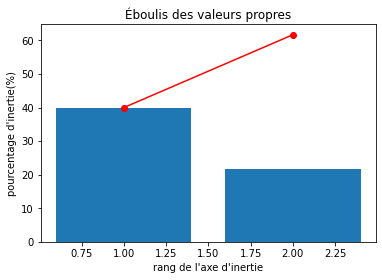

```python
# Nombre de composants principales souhaités
n_comp = 2
# Calcul des composants principales
pca = decomposition.PCA(n_components=n_comp)
pca.fit(X_scaled)

display_scree_plot(pca)
plt.show()
```

```python
# Variance expliquée
pca.explained_variance_
```

```
array([4.02361338, 2.18531978])
```

```python
# Proportion de variance expliquée
pca.explained_variance_ratio_
```

```
array([0.39992278, 0.21720754])
```

```python
# Cumul de variance expliqué
pca.explained_variance_ratio_.sum()
```

```
0.6171303265132065
```

## Cercle des corrélations sans les outliers

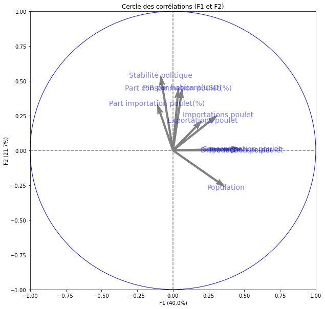

```python
# Cercle des corrélations sans les outliers
pcs = pca.components_
display_circles(pcs, n_comp, pca, [(0, 1)], labels=np.array(features))

plt.show()
```

```python
F1 = pca.components_[0]
F1
```

```
array([ 0.37026927,  0.48289744,  0.2073841 ,  0.31607524,  0.47751015,
        0.48256858, -0.11175702,  0.03829379, -0.08759862,  0.06542981])
```

```python
F2 = pca.components_[1]
F2
```

```
array([-0.26584632,  0.00602185,  0.21880007,  0.25634109,  0.00312326,
        0.01258591,  0.33726368,  0.45049622,  0.54289369,  0.45178522])
```

Sans les outliers, on a les variables, production, consommation et dispo intérieure qui sont très corrélées positivement à F1, la population est aussi corrélée à F1, mais pas très fort, l’importation est un peu corrélée à la fois à F1 et F2. Les variables, stabilité politique, part consommation poulet, PIB par habitant sont très corrélées positivement à F2.

On peut synthétiser le F1 la demande de poulet, et le F2 le développement d’un pays.

## Projection des individus sur F1 et F2 sans les outliers

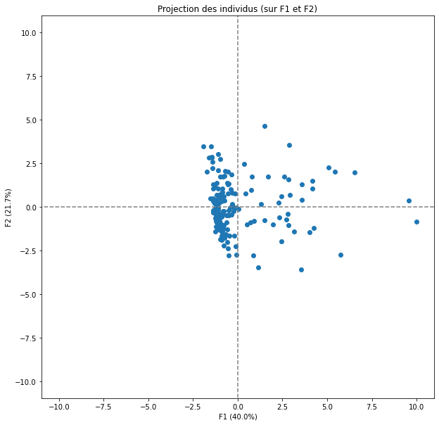

```python
# Projection des individus sur F1 et F2 sans les outliers
X_projected = pca.transform(X_scaled)
display_factorial_planes(X_projected, n_comp, pca, [(0, 1)])

plt.show()
```

Sans les outliers, les points sont plus groupés, pas des points très isolés. On va ensuite créer des groupes à l’aide méthode KMeans.

# Analyses non supervisées - Kmeans

```python
from sklearn.cluster import KMeans
```

## Calcul de nombre de clusters

Je vais d’abord déterminer le nombre optimal de clusters.

### Méthode Elbow

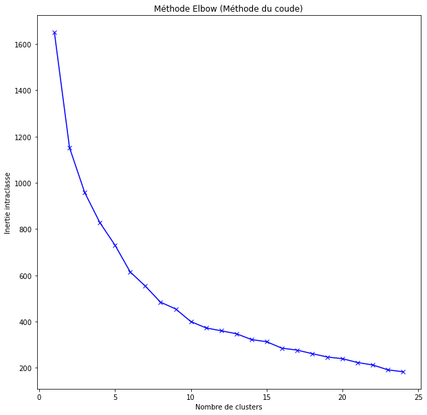

```python
a = []
for i in range(1, 25):
    km = KMeans(n_clusters=i)
    km.fit(X_scaled)
    a.append(km.inertia_)
fig = plt.figure(figsize=(10, 10))
plt.plot(range(1, 25), a, 'bx-')
plt.title('Méthode Elbow (Méthode du coude)')
plt.xlabel('Nombre de clusters')
plt.ylabel('Inertie intraclasse')
plt.show()
```

La méthode de coude n'est pas très clair pour déterminer une bonne valeur du nombre de clusters, on va utiliser la méthode Sihouette.

### Méthode Sihouette

```
Pour n_clusters=2, Silhouette Coefficient = 0.47429159350085276
Pour n_clusters=3, Silhouette Coefficient = 0.2868029505765589
Pour n_clusters=4, Silhouette Coefficient = 0.4115859901052178
Pour n_clusters=5, Silhouette Coefficient = 0.34099643854972894
Pour n_clusters=6, Silhouette Coefficient = 0.31772792805938527
Pour n_clusters=7, Silhouette Coefficient = 0.26439599933381885
```

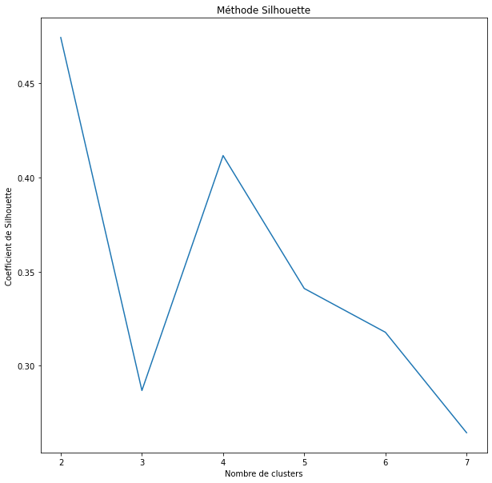

```python
from sklearn import metrics

k_clusters = []
sil_coeffecients = []

for n_cluster in range(2, 8):
    kmeans = KMeans(n_clusters=n_cluster, random_state=10).fit(X_scaled)
    label = kmeans.labels_
    sil_coeff = metrics.silhouette_score(X_scaled, label)
    print("Pour n_clusters={}, Silhouette Coefficient = {}".format(
        n_cluster, sil_coeff))
    sil_coeffecients.append(sil_coeff)
    k_clusters.append(n_cluster)

# graphique
fig = plt.figure(figsize=(10, 10))
plt.title("Méthode Silhouette")
plt.xlabel("Nombre de clusters")
plt.ylabel("Coefficient de Silhouette")
plt.plot(k_clusters, sil_coeffecients)
plt.show()
```

```
Pour n_clusters = 2 , le score moyen de silhouette est de : 0.47429159350085276
Pour n_clusters = 3 , le score moyen de silhouette est de : 0.2868029505765589
Pour n_clusters = 4 , le score moyen de silhouette est de : 0.4115859901052178
Pour n_clusters = 5 , le score moyen de silhouette est de : 0.34099643854972894
Pour n_clusters = 6 , le score moyen de silhouette est de : 0.31772792805938527
Pour n_clusters = 7 , le score moyen de silhouette est de : 0.26439599933381885
```

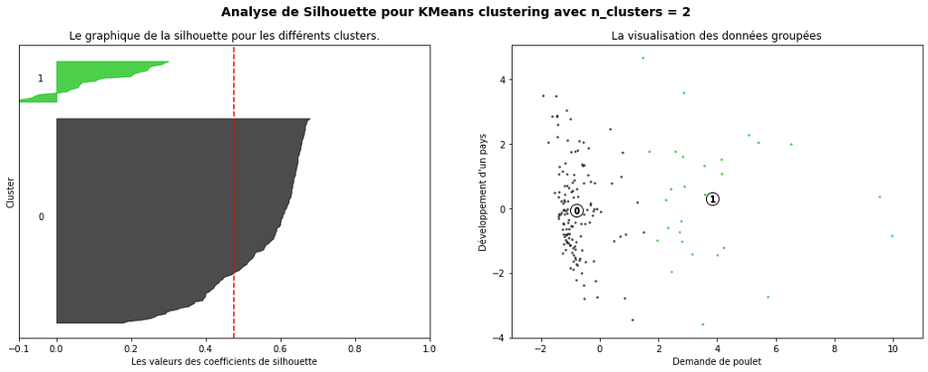

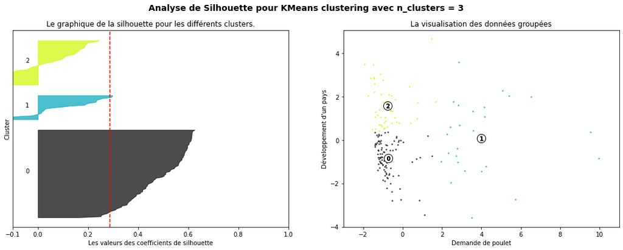

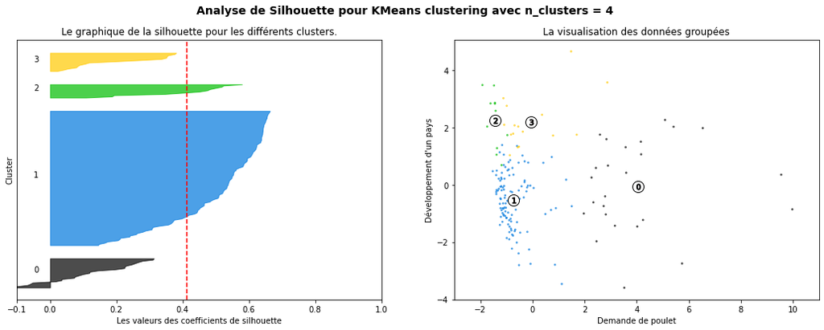

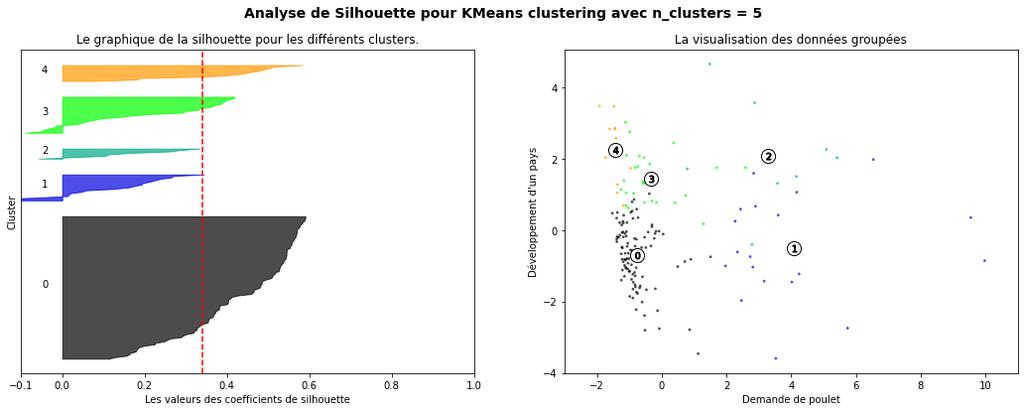

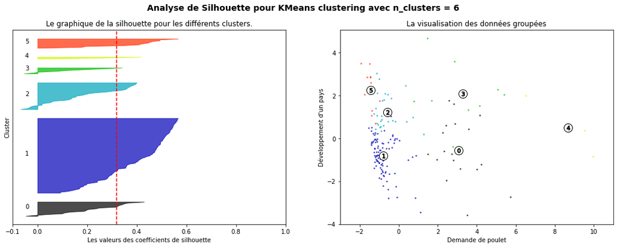

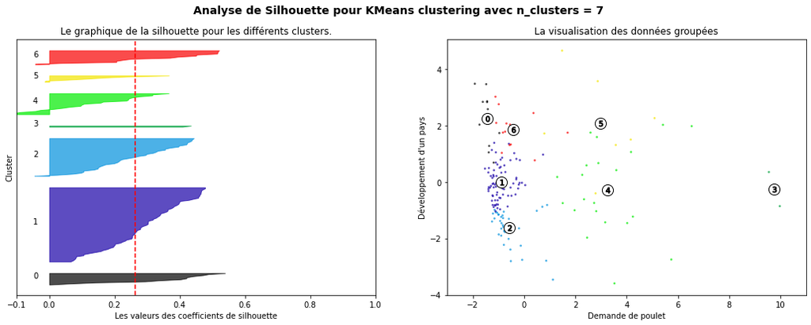

```python
import matplotlib.cm as cm

range_n_clusters = [2, 3, 4, 5, 6, 7]

for n_clusters in range_n_clusters:
    # Création de subplot avec 1 ligne et 2 colonnes
    fig, (ax1, ax2) = plt.subplots(1, 2)
    fig.set_size_inches(18, 6)

    # Le premier subplot est le graphique de Silouette
    # Le coefficient Silhouette peut être entre -1, 1,
    # Mais pour notre example, on va mettre entre [-0.1, 1]
    ax1.set_xlim([-0.1, 1])
    # Le (n_clusters+1)*10 sert à insérer un espace vide entre la Silhouette
    # Parcelles de clusters individuels, pour les délimiter clairement.
    ax1.set_ylim([0, len(X_scaled) + (n_clusters + 1) * 10])

    # Initialiser le clusterer avec la valeur n_clusters et un générateur aléatoire
    clusterer = KMeans(n_clusters=n_clusters, random_state=10)
    cluster_labels = clusterer.fit_predict(X_scaled)

    # Le score Silhouette donne la valeur moyenne pour tous les échantillons.
    # Cela donne une perspective sur la densité et la séparation de la forme clusters
    silhouette_avg = metrics.silhouette_score(X_scaled, cluster_labels)
    print("Pour n_clusters =", n_clusters, ",",
          "le score moyen de silhouette est de :", silhouette_avg,)

    # Calculer les scores de silhouette pour chaque échantillon
    sample_silhouette_values = metrics.silhouette_samples(
        X_scaled, cluster_labels)

    y_lower = 10
    for i in range(n_clusters):
        # Agréger les scores de silhouette pour les échantillons appartenant au cluster i, et les trier
        ith_cluster_silhouette_values = sample_silhouette_values[cluster_labels == i]

        ith_cluster_silhouette_values.sort()

        size_cluster_i = ith_cluster_silhouette_values.shape[0]
        y_upper = y_lower + size_cluster_i

        color = cm.nipy_spectral(float(i) / n_clusters)
        ax1.fill_betweenx(np.arange(y_lower, y_upper), 0, ith_cluster_silhouette_values,
                          facecolor=color, edgecolor=color, alpha=0.7,)

        # Étiquetez les parcelles de silhouette avec leurs numéros de cluster au milieu
        ax1.text(-0.05, y_lower + 0.5 * size_cluster_i, str(i))

        # Calculer le nouveau y_lower pour le prochain tracé
        y_lower = y_upper + 10  # 10 pour les 0 échantillons

    ax1.set_title("Le graphique de la silhouette pour les différents clusters.")
    ax1.set_xlabel("Les valeurs des coefficients de silhouette")
    ax1.set_ylabel("Cluster")

    # La ligne verticale pour le score de silhouette moyen de toutes les valeurs
    ax1.axvline(x=silhouette_avg, color="red", linestyle="--")

    ax1.set_yticks([])  # Effacer les étiquettes / ticks de l'axe Y
    ax1.set_xticks([-0.1, 0, 0.2, 0.4, 0.6, 0.8, 1])

    # 2ème graphique montrant les clusters réels formés
    X_projected = pca.transform(X_scaled)
    colors = cm.nipy_spectral(cluster_labels.astype(float) / n_clusters)
    ax2.scatter(X_projected[:, 0], X_projected[:, 1], marker=".",
                s=30, lw=0, alpha=0.7, c=colors, edgecolor="k")

    # Étiquetez les clusters
    centroids = clusterer.cluster_centers_
    centroids_projected = pca.transform(centroids)
    # Dessinez des cercles blancs au centre des clusters
    ax2.scatter(centroids_projected[:, 0], centroids_projected[:, 1],
                marker="o", c="white", alpha=1, s=200, edgecolor="k",)

    for i, c in enumerate(centroids_projected):
        ax2.scatter(c[0], c[1], marker="$%d$" %
                    i, alpha=1, s=50, edgecolor="k")

    ax2.set_title("La visualisation des données groupées")
    ax2.set_xlabel("Demande de poulet")
    ax2.set_ylabel("Développement d'un pays")
    ax2.set_xlim([-4, 5])
    ax2.set_xlim([-3, 11])

    plt.suptitle("Analyse de Silhouette pour KMeans clustering avec n_clusters = %d" %
                 n_clusters, fontsize=14, fontweight="bold",)

plt.show()
```

Selon le méthode de Silouette et les graphiques, 2 ou 4 semblent les bonnes valeurs pour le nombre de clusters.

On va donc projeter les individus groupés sur le plan factoriel avec nombre de clusters égale 2 et 4, et les centroïde de chaque cluster. Normalement, 2 clusters sont le meilleur choix, mais dans notre cas, 2 groupes des pays, je trouve que c’est très limite pour notre analyse, car chaque groupe aura un grand nombre de pays, et pas très intéressant pour une analyse approfondie si on veut un résultat plus précis. Donc, je vais choisir 4 clusters.

## Affichage du clustering

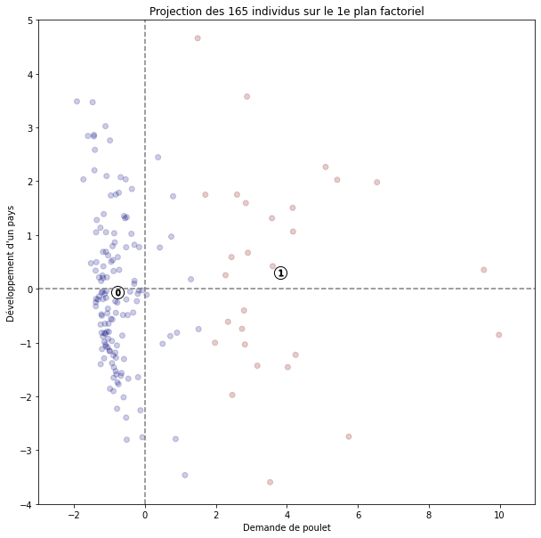

```python
# Nombre de clusters souhaités
n_clust = 2

# Clustering par K-means
km = KMeans(n_clusters=n_clust, random_state=10)
km.fit(X_scaled)

# Récupération des clusters attribués à chaque individu
clusters = km.labels_

# Affichage du clustering par projection des individus sur le premier plan factoriel

X_projected = pca.transform(X_scaled)
fig = plt.figure(figsize=(10, 10))
plt.scatter(X_projected[:, 0], X_projected[:, 1],
            c=clusters.astype(np.float64), cmap='jet', alpha=0.2)
plt.title("Projection des {} individus sur le 1e plan factoriel".format(
    X_projected.shape[0]))
plt.xlabel("Demande de poulet")
plt.ylabel("Développement d'un pays")

# affichage des lignes horizontales et verticales
plt.plot([-3, 11], [0, 0], color='grey', ls='--')
plt.plot([0, 0], [-4, 5], color='grey', ls='--')

# Affichage des positions des centres de classes
centroids = km.cluster_centers_
centroids_projected = pca.transform(centroids)
plt.scatter(centroids_projected[:, 0], centroids_projected[:, 1],
            marker="o", c="white", alpha=1, s=200, edgecolor="k")
for i, c in enumerate(centroids_projected):
    plt.scatter(c[0], c[1], marker="$%d$" % i, alpha=1, s=50, edgecolor="k")

# définition des limites du graphique
plt.xlim([-3, 11])
plt.ylim([-4, 5])

plt.show(block=False)
```

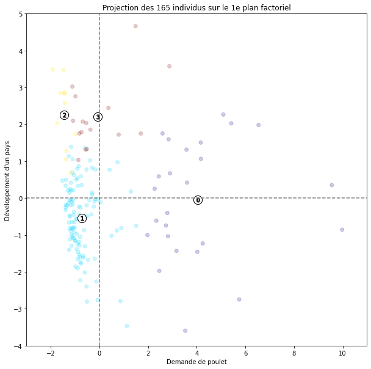

```python
# Nombre de clusters souhaités
n_clust = 4

# Clustering par K-means
km = KMeans(n_clusters=n_clust, random_state=10)
km.fit(X_scaled)

# Récupération des clusters attribués à chaque individu
clusters = km.labels_

# Affichage du clustering par projection des individus sur le premier plan factoriel

X_projected = pca.transform(X_scaled)
fig = plt.figure(figsize=(10, 10))
plt.scatter(X_projected[:, 0], X_projected[:, 1],
            c=clusters.astype(np.float64), cmap='jet', alpha=0.2)
plt.title("Projection des {} individus sur le 1e plan factoriel".format(
    X_projected.shape[0]))
plt.xlabel("Demande de poulet")
plt.ylabel("Développement d'un pays")

# affichage des lignes horizontales et verticales
plt.plot([-3, 11], [0, 0], color='grey', ls='--')
plt.plot([0, 0], [-4, 5], color='grey', ls='--')

# Affichage des positions des centres de classes
centroids = km.cluster_centers_
centroids_projected = pca.transform(centroids)
plt.scatter(centroids_projected[:, 0], centroids_projected[:, 1],
            marker="o", c="white", alpha=1, s=200, edgecolor="k")
for i, c in enumerate(centroids_projected):
    plt.scatter(c[0], c[1], marker="$%d$" % i, alpha=1, s=50, edgecolor="k")

# définition des limites du graphique
plt.xlim([-3, 11])
plt.ylim([-4, 5])

plt.show(block=False)
```

Si on regarde que les variables du premier plan factoriel, on peut conclure :

- Cluster 0 : Les pays ayant beaucoup de demande de poulet.
- Cluster 1 : Les pays peu développés et pas beaucoup de demande de poulet.
- Cluster 2 : Les pays bien développés et avec une demande de poulet relativement moins importantes.
- Cluster 3 : Les pays bien développés et avec une demande moyenne de poulet.

Je vais aussi tester avec la classification ascendante hiérarchique pour voir les groupes des pays.

# Analyses non supervisées - Classification ascendante hiérarchique

```python
from scipy.cluster.hierarchy import dendrogram, linkage, fcluster
```

## Dendrogramme de hiérarchie de clusters

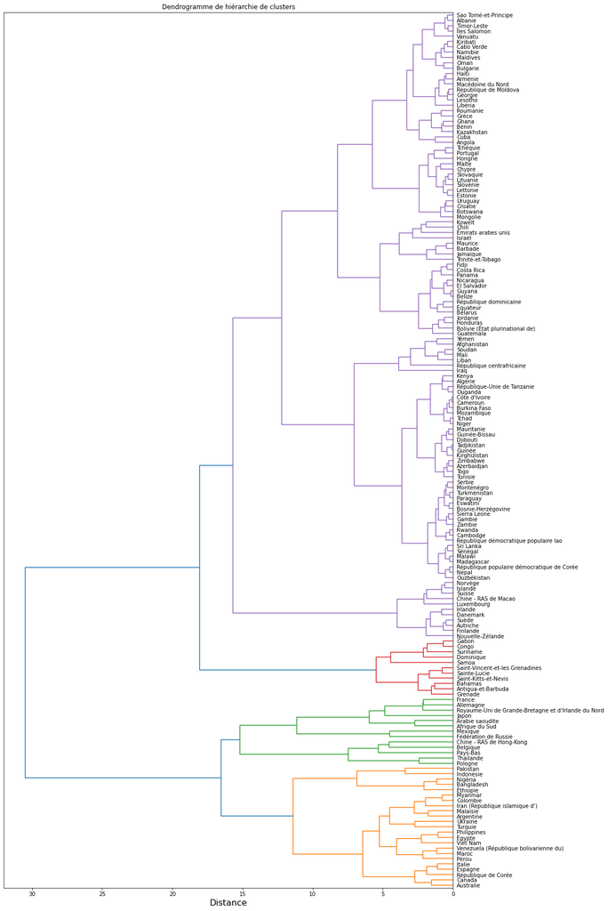

```python
Z = linkage(X_scaled, 'ward')
fig = plt.figure(figsize=(15, 30))
plt.title('Dendrogramme de hiérarchie de clusters')
plt.xlabel('Distance', fontsize=16)
den = dendrogram(Z, orientation='left', leaf_font_size=10,
           labels=data1.index, color_threshold=16)
plt.show()
```

On va aussi choisir le nombre de classe du dendrogramme égale 4.

Et on va faire une vérification avec Heatmap, pour voir si les variables corroborent bien mes groupes. Et si les groupes tirés de KMeans sont bien corresponds à ceux tirés du Dendrogramme.

# Heatmap entre les clusters de pays et les différentes variables

```python
import seaborn as sns
sns.set(rc={'figure.figsize': (10, 10)}, font_scale=1.4)
```

```python
# Préparation des données centrées réduites
data2 = pd.DataFrame(X_scaled, names, columns=features)
data2
```

| Zone | Population | Dispo intérieure poulet | Exportations poulet | Importations poulet | Production poulet | Consommation poulet | Part importation poulet(%) | Part consommation poulet(%) | Stabilité politique | PIB par habitant(USD) |
| --- | --- | --- | --- | --- | --- | --- | --- | --- | --- | --- |
| Afghanistan | 0.294779 | -0.477145 | -0.312794 | -0.314303 | -0.505518 | -0.470079 | -0.493062 | -0.993688 | -3.027883 | -0.685775 |
| Afrique du Sud | 0.814923 | 2.389390 | 0.035257 | 2.286205 | 1.824947 | 2.414010 | 0.883627 | 1.430561 | -0.237436 | -0.393523 |
| Albanie | -0.544236 | -0.491053 | -0.312794 | -0.266046 | -0.526846 | -0.481732 | 0.502725 | -0.641585 | 0.493395 | -0.477293 |
| Algérie | 0.422672 | -0.171158 | -0.312794 | -0.459074 | -0.154313 | -0.165648 | -0.664468 | -0.839896 | -0.946121 | -0.498370 |
| Allemagne | 1.458992 | 1.862259 | 3.256109 | 4.044900 | 1.607399 | 1.793494 | -0.321656 | -0.329954 | 0.725932 | 1.608921 |
| ... | ... | ... | ... | ... | ... | ... | ... | ... | ... | ... |
| Venezuela (République bolivarienne du) | 0.121671 | 0.314247 | -0.312794 | -0.335751 | 0.307799 | 0.317947 | -0.520270 | 0.374252 | -1.311537 | -0.273305 |
| Viet Nam | 1.758876 | 1.120938 | -0.307269 | 1.090508 | 0.759957 | 1.148215 | -0.357026 | -0.463510 | 0.393736 | -0.589252 |
| Yémen | 0.082305 | -0.214275 | -0.312794 | -0.051571 | -0.306454 | -0.204976 | -0.321656 | -0.022370 | -3.182908 | -0.673686 |
| Zambie | -0.193447 | -0.472972 | -0.307269 | -0.405455 | -0.475658 | -0.465709 | -0.046863 | -0.771094 | 0.238711 | -0.632534 |
| Zimbabwe | -0.259163 | -0.450719 | -0.312794 | -0.437626 | -0.447221 | -0.452600 | -0.514828 | -0.601114 | -0.713584 | -0.631840 |

165 rows × 10 columns

## Heatmap - dendrogramme

```python
# Coupage du dendrogramme en 4 clusters
groupes_cah = fcluster(Z, 4, criterion='maxclust')
print (groupes_cah)
```

```
[4 2 4 4 2 4 3 2 1 4 1 4 4 3 1 4 4 2 4 4 4 4 4 4 4 4 4 4 1 4 2 4 4 1 3 4 4
 4 4 4 4 3 1 4 4 4 1 4 4 1 2 4 4 2 3 4 4 4 4 3 4 4 4 4 4 4 4 4 1 1 4 4 4 4
 1 4 2 4 4 4 4 4 4 4 4 4 4 4 4 4 4 1 4 4 4 4 1 4 4 2 4 4 4 1 4 4 4 4 1 4 4
 4 4 4 1 4 4 2 1 1 2 4 4 1 4 4 4 4 4 4 2 4 3 3 3 3 4 4 4 4 4 4 4 4 4 4 3 4
 4 4 2 4 4 4 4 4 1 1 4 4 1 1 4 4 4]
```

```python
# index triés des groupes CAH
idg = np.argsort(groupes_cah)
# affichage des observations et leurs groupes
groupe_CAH = pd.DataFrame(
    groupes_cah[idg], data1.index[idg], columns=['Groupe'])
groupe_CAH
```

| Zone | Groupe |
| --- | --- |
| Pakistan | 1 |
| Canada | 1 |
| Myanmar | 1 |
| Égypte | 1 |
| Iran (République islamique d') | 1 |
| ... | ... |
| Iraq | 4 |
| Irlande | 4 |
| Islande | 4 |
| Haïti | 4 |
| Zimbabwe | 4 |

165 rows × 1 columns

```python
# Préparation des données pour heatmap entre groupes tirés de dendrogramme et les variables
df = pd.concat([data2, groupe_CAH], axis=1).reset_index()
```

```python
df
```

|  | Zone | Population | Dispo intérieure poulet | Exportations poulet | Importations poulet | Production poulet | Consommation poulet | Part importation poulet(%) | Part consommation poulet(%) | Stabilité politique | PIB par habitant(USD) | Groupe |
| --- | --- | --- | --- | --- | --- | --- | --- | --- | --- | --- | --- | --- |
| 0 | Afghanistan | 0.294779 | -0.477145 | -0.312794 | -0.314303 | -0.505518 | -0.470079 | -0.493062 | -0.993688 | -3.027883 | -0.685775 | 4 |
| 1 | Afrique du Sud | 0.814923 | 2.389390 | 0.035257 | 2.286205 | 1.824947 | 2.414010 | 0.883627 | 1.430561 | -0.237436 | -0.393523 | 2 |
| 2 | Albanie | -0.544236 | -0.491053 | -0.312794 | -0.266046 | -0.526846 | -0.481732 | 0.502725 | -0.641585 | 0.493395 | -0.477293 | 4 |
| 3 | Algérie | 0.422672 | -0.171158 | -0.312794 | -0.459074 | -0.154313 | -0.165648 | -0.664468 | -0.839896 | -0.946121 | -0.498370 | 4 |
| 4 | Allemagne | 1.458992 | 1.862259 | 3.256109 | 4.044900 | 1.607399 | 1.793494 | -0.321656 | -0.329954 | 0.725932 | 1.608921 | 2 |
| ... | ... | ... | ... | ... | ... | ... | ... | ... | ... | ... | ... | ... |
| 160 | Venezuela (République bolivarienne du) | 0.121671 | 0.314247 | -0.312794 | -0.335751 | 0.307799 | 0.317947 | -0.520270 | 0.374252 | -1.311537 | -0.273305 | 1 |
| 161 | Viet Nam | 1.758876 | 1.120938 | -0.307269 | 1.090508 | 0.759957 | 1.148215 | -0.357026 | -0.463510 | 0.393736 | -0.589252 | 1 |
| 162 | Yémen | 0.082305 | -0.214275 | -0.312794 | -0.051571 | -0.306454 | -0.204976 | -0.321656 | -0.022370 | -3.182908 | -0.673686 | 4 |
| 163 | Zambie | -0.193447 | -0.472972 | -0.307269 | -0.405455 | -0.475658 | -0.465709 | -0.046863 | -0.771094 | 0.238711 | -0.632534 | 4 |
| 164 | Zimbabwe | -0.259163 | -0.450719 | -0.312794 | -0.437626 | -0.447221 | -0.452600 | -0.514828 | -0.601114 | -0.713584 | -0.631840 | 4 |

165 rows × 12 columns

```python
# Réorganisation des données
data_heatmap_CAH = pd.melt(df, id_vars=['Zone','Groupe'])
data_heatmap_CAH
```

|  | Zone | Groupe | variable | value |
| --- | --- | --- | --- | --- |
| 0 | Afghanistan | 4 | Population | 0.294779 |
| 1 | Afrique du Sud | 2 | Population | 0.814923 |
| 2 | Albanie | 4 | Population | -0.544236 |
| 3 | Algérie | 4 | Population | 0.422672 |
| 4 | Allemagne | 2 | Population | 1.458992 |
| ... | ... | ... | ... | ... |
| 1645 | Venezuela (République bolivarienne du) | 1 | PIB par habitant(USD) | -0.273305 |
| 1646 | Viet Nam | 1 | PIB par habitant(USD) | -0.589252 |
| 1647 | Yémen | 4 | PIB par habitant(USD) | -0.673686 |
| 1648 | Zambie | 4 | PIB par habitant(USD) | -0.632534 |
| 1649 | Zimbabwe | 4 | PIB par habitant(USD) | -0.631840 |

1650 rows × 4 columns

```python
# Calcul de la valeur moyenne de chaque variables pour chaque groupe
data_heatmap_CAH = data_heatmap_CAH.pivot_table(
    index="variable", columns="Groupe", values='value', aggfunc='mean')
data_heatmap_CAH
```

| Groupe variable | 1 | 2 | 3 | 4 |
| --- | --- | --- | --- | --- |
| Consommation poulet | 1.121300 | 1.976243 | -0.516823 | -0.388102 |
| Dispo intérieure poulet | 1.189150 | 1.918214 | -0.518996 | -0.394731 |
| Exportations poulet | 0.075371 | 2.352196 | -0.310283 | -0.244907 |
| Importations poulet | -0.081411 | 2.640089 | -0.333314 | -0.243917 |
| PIB par habitant(USD) | -0.075305 | 0.764707 | -0.133714 | -0.057104 |
| Part consommation poulet(%) | -0.020962 | 0.372384 | 2.017399 | -0.225002 |
| Part importation poulet(%) | -0.515183 | -0.036189 | 3.049823 | -0.179902 |
| Population | 1.485591 | 1.015684 | -0.596244 | -0.345880 |
| Production poulet | 1.261264 | 1.957511 | -0.541582 | -0.411011 |
| Stabilité politique | -0.663514 | 0.246377 | 0.793378 | 0.028227 |

### Affichage de Heatmap - dendrogramme

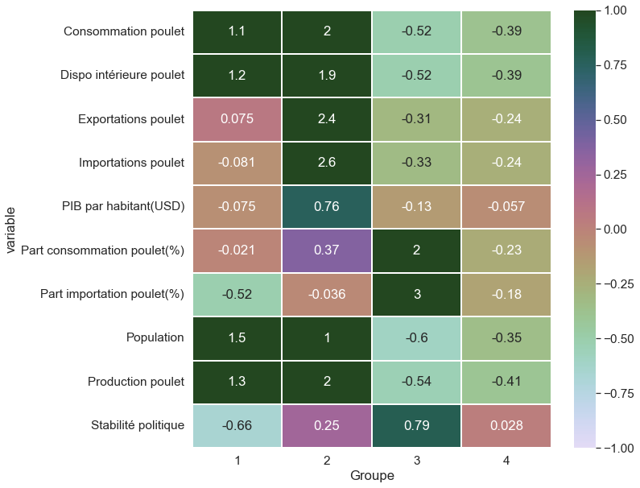

```python
cmap = sns.cubehelix_palette(start=1, rot=2, gamma=0.8, as_cmap=True)
heatmap = sns.heatmap(data_heatmap_CAH, linewidths=0.05,
                      vmin=-1, vmax=1, annot=True, cmap=cmap)
fig = heatmap.get_figure()
```

## Heatmap - Kmeans

```python
# Récupération des clusters attribués à chaque individu
print (clusters)
```

```
[1 0 1 1 0 1 2 0 0 1 3 3 1 2 1 1 1 3 1 1 1 1 1 1 1 1 1 1 0 1 3 3 1 0 2 1 1
 1 1 3 1 2 0 1 3 1 0 1 1 1 0 1 3 0 2 1 1 1 1 2 1 1 1 1 1 1 1 1 0 0 1 3 3 1
 0 1 0 1 1 1 1 1 1 1 1 1 1 1 3 1 1 0 1 1 1 1 1 1 1 0 1 1 1 0 1 1 1 1 1 3 3
 1 1 1 0 1 1 3 1 0 0 1 1 1 1 1 1 1 1 1 0 1 2 2 2 2 1 1 1 1 1 1 1 1 3 3 2 1
 1 1 0 1 1 2 1 1 0 0 1 1 1 0 1 1 1]
```

```python
# index triés des groupes Kmeans
idk = np.argsort(clusters)
# affichage des observations et leurs groupes
groupe_Kmeans = pd.DataFrame(
    km.labels_[idk], data1.index[idk], columns=['Cluster'])
groupe_Kmeans
```

| Zone | Cluster |
| --- | --- |
| Pologne | 0 |
| Fédération de Russie | 0 |
| Philippines | 0 |
| Égypte | 0 |
| France | 0 |
| ... | ... |
| Chine - RAS de Macao | 3 |
| Danemark | 3 |
| Suisse | 3 |
| Nouvelle-Zélande | 3 |
| Irlande | 3 |

165 rows × 1 columns

```python
# Correspondance CAH – Kmeans
pd.crosstab(groupes_cah,km.labels_)
```

| col_0 row_0 | 0 | 1 | 2 | 3 |
| --- | --- | --- | --- | --- |
| 1 | 15 | 7 | 0 | 1 |
| 2 | 10 | 0 | 0 | 3 |
| 3 | 0 | 0 | 11 | 0 |
| 4 | 0 | 105 | 1 | 12 |

Il y a certes des correspondances pour les groupes entre deux méthodes d'analyse non supervisées, mais elles ne sont pas exactes.

```python
# Préparation des données pour heatmap entre clusters tirés de Kmeans et les variables
df1 = pd.concat([data2, groupe_Kmeans], axis=1).reset_index()
df1
```

|  | Zone | Population | Dispo intérieure poulet | Exportations poulet | Importations poulet | Production poulet | Consommation poulet | Part importation poulet(%) | Part consommation poulet(%) | Stabilité politique | PIB par habitant(USD) | Cluster |
| --- | --- | --- | --- | --- | --- | --- | --- | --- | --- | --- | --- | --- |
| 0 | Afghanistan | 0.294779 | -0.477145 | -0.312794 | -0.314303 | -0.505518 | -0.470079 | -0.493062 | -0.993688 | -3.027883 | -0.685775 | 1 |
| 1 | Afrique du Sud | 0.814923 | 2.389390 | 0.035257 | 2.286205 | 1.824947 | 2.414010 | 0.883627 | 1.430561 | -0.237436 | -0.393523 | 0 |
| 2 | Albanie | -0.544236 | -0.491053 | -0.312794 | -0.266046 | -0.526846 | -0.481732 | 0.502725 | -0.641585 | 0.493395 | -0.477293 | 1 |
| 3 | Algérie | 0.422672 | -0.171158 | -0.312794 | -0.459074 | -0.154313 | -0.165648 | -0.664468 | -0.839896 | -0.946121 | -0.498370 | 1 |
| 4 | Allemagne | 1.458992 | 1.862259 | 3.256109 | 4.044900 | 1.607399 | 1.793494 | -0.321656 | -0.329954 | 0.725932 | 1.608921 | 0 |
| ... | ... | ... | ... | ... | ... | ... | ... | ... | ... | ... | ... | ... |
| 160 | Venezuela (République bolivarienne du) | 0.121671 | 0.314247 | -0.312794 | -0.335751 | 0.307799 | 0.317947 | -0.520270 | 0.374252 | -1.311537 | -0.273305 | 1 |
| 161 | Viet Nam | 1.758876 | 1.120938 | -0.307269 | 1.090508 | 0.759957 | 1.148215 | -0.357026 | -0.463510 | 0.393736 | -0.589252 | 0 |
| 162 | Yémen | 0.082305 | -0.214275 | -0.312794 | -0.051571 | -0.306454 | -0.204976 | -0.321656 | -0.022370 | -3.182908 | -0.673686 | 1 |
| 163 | Zambie | -0.193447 | -0.472972 | -0.307269 | -0.405455 | -0.475658 | -0.465709 | -0.046863 | -0.771094 | 0.238711 | -0.632534 | 1 |
| 164 | Zimbabwe | -0.259163 | -0.450719 | -0.312794 | -0.437626 | -0.447221 | -0.452600 | -0.514828 | -0.601114 | -0.713584 | -0.631840 | 1 |

165 rows × 12 columns

```python
# Réorganisation des données
data_heatmap_kmeans = pd.melt(df1, id_vars=['Zone','Cluster'])
data_heatmap_kmeans
```

|  | Zone | Cluster | variable | value |
| --- | --- | --- | --- | --- |
| 0 | Afghanistan | 1 | Population | 0.294779 |
| 1 | Afrique du Sud | 0 | Population | 0.814923 |
| 2 | Albanie | 1 | Population | -0.544236 |
| 3 | Algérie | 1 | Population | 0.422672 |
| 4 | Allemagne | 0 | Population | 1.458992 |
| ... | ... | ... | ... | ... |
| 1645 | Venezuela (République bolivarienne du) | 1 | PIB par habitant(USD) | -0.273305 |
| 1646 | Viet Nam | 0 | PIB par habitant(USD) | -0.589252 |
| 1647 | Yémen | 1 | PIB par habitant(USD) | -0.673686 |
| 1648 | Zambie | 1 | PIB par habitant(USD) | -0.632534 |
| 1649 | Zimbabwe | 1 | PIB par habitant(USD) | -0.631840 |

1650 rows × 4 columns

```python
# Calcul de la valeur moyenne de chaque variables pour chaque cluster
data_heatmap_kmeans = data_heatmap_kmeans.pivot_table(
    index="variable", columns="Cluster", values='value', aggfunc='mean')
data_heatmap_kmeans
```

| Cluster variable | 0 | 1 | 2 | 3 |
| --- | --- | --- | --- | --- |
| Consommation poulet | 2.003129 | -0.360911 | -0.510500 | -0.220635 |
| Dispo intérieure poulet | 1.991941 | -0.354800 | -0.513307 | -0.243830 |
| Exportations poulet | 0.814228 | -0.263911 | -0.310492 | 0.808013 |
| Importations poulet | 1.055334 | -0.268296 | -0.334410 | 0.479924 |
| PIB par habitant(USD) | 0.117527 | -0.368850 | -0.111718 | 2.482101 |
| Part consommation poulet(%) | 0.251542 | -0.302780 | 2.111496 | 0.142805 |
| Part importation poulet(%) | -0.343857 | -0.197377 | 2.811265 | -0.189531 |
| Population | 1.498458 | -0.210551 | -0.595049 | -0.421195 |
| Production poulet | 2.020940 | -0.367316 | -0.534667 | -0.185506 |
| Stabilité politique | -0.362342 | -0.176929 | 0.759152 | 1.235300 |

### Affichage de Heatmap - kmeans

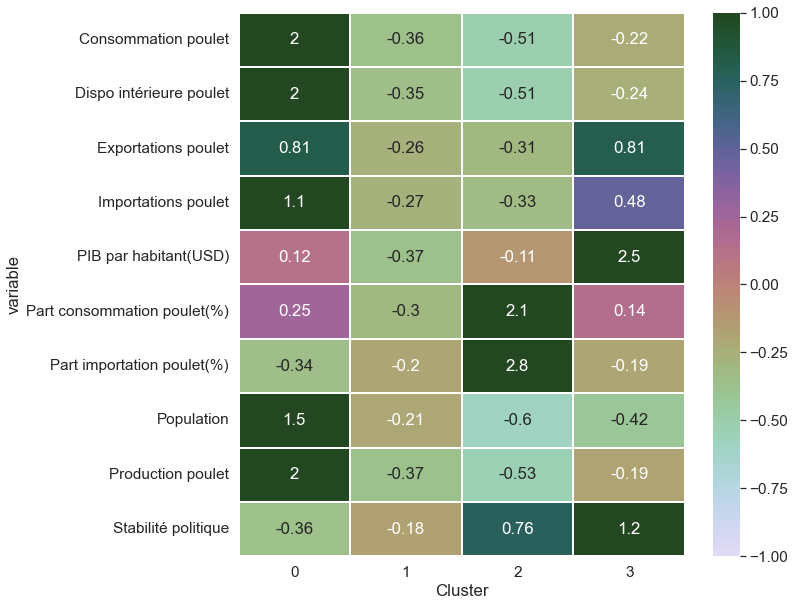

```python
heatmap = sns.heatmap(data_heatmap_kmeans, linewidths=0.05,
                      vmin=-1, vmax=1, annot=True, cmap=cmap)
fig = heatmap.get_figure()
```

Comme on a dit, la dimension 1 qui regroupe les variables comme dispo intérieure, consommation, production et population. En regardant le graphique, le cluster 0 est bien influencé par la dimension 1, ça correspond bien au Heatmap.

La dimension 2 représente les variables comme PIB par habitant, stabilité politique, part consommation poulet, et aussi un peu part d’importation des poulets. On peut voir la position du cluster 1 sur le graphique, plupart d’entre les pays du cluster 1 sont influencés négativement par la dimension 1 et 2, donc, ça correspond aussi au Heatmap, les valeurs de toutes ces variables pour le cluster 1 sont relativement faible par rapport aux autres clusters.

Donc, ici, on peut dire que le Heatmap corrobore bien les clusters, à part que les clusters 2 et 3 sont un peu influencé par peut être la dimension 3, une autre variable synthétique, je ne vais pas analyser plus, car on a déjà le groupe des pays de cluster 0 qui sera les pays ciblés.

# Résultat - Pays ciblés et recommandés

```python
# Identification des pays ciblés de cluster 1
std_scale = preprocessing.StandardScaler().fit(X)
X_scaled = std_scale.transform(X)

n_comp = 2
pca = decomposition.PCA(n_components=n_comp, random_state=15)
pca.fit(X_scaled)
X_projected = pca.transform(X_scaled)

Pays_cible = pd.DataFrame(X_projected, index=data1.index, columns=[
                          "F"+str(i+1) for i in range(2)])

Pays_cible = pd.concat([Pays_cible, groupe_Kmeans], axis=1)
Pays_cible = Pays_cible[Pays_cible['Cluster'] == 0]

Pays_cible
```

| Zone | F1 | F2 | Cluster |
| --- | --- | --- | --- |
| Afrique du Sud | 4.172933 | 1.063376 | 0 |
| Allemagne | 5.091284 | 2.264116 | 0 |
| Arabie saoudite | 2.841366 | 1.593267 | 0 |
| Argentine | 3.599966 | 0.419722 | 0 |
| Canada | 2.592805 | 1.751053 | 0 |
| Colombie | 2.733956 | -0.743531 | 0 |
| Égypte | 2.460657 | -1.972847 | 0 |
| Espagne | 2.899655 | 0.669638 | 0 |
| Fédération de Russie | 9.979901 | -0.856950 | 0 |
| France | 4.161795 | 1.504598 | 0 |
| Indonésie | 5.745246 | -2.748107 | 0 |
| Iran (République islamique d') | 4.245779 | -1.228288 | 0 |
| Italie | 2.269454 | 0.252616 | 0 |
| Japon | 6.540764 | 1.979629 | 0 |
| Malaisie | 2.437316 | 0.588878 | 0 |
| Mexique | 9.553438 | 0.351783 | 0 |
| Myanmar | 2.816076 | -1.035466 | 0 |
| Pakistan | 3.526232 | -3.594996 | 0 |
| Philippines | 3.166529 | -1.430241 | 0 |
| Pologne | 3.578488 | 1.312251 | 0 |
| Royaume-Uni de Grande-Bretagne et d'Irlande du Nord | 5.419068 | 2.025795 | 0 |
| Thaïlande | 2.789761 | -0.403836 | 0 |
| Turquie | 4.024046 | -1.456850 | 0 |
| Ukraine | 1.971810 | -1.002999 | 0 |
| Viet Nam | 2.339601 | -0.613384 | 0 |

```python
# Choix des pays recommandés pour exporter nos poulets parmi les pays ciblés.
Pays_recommande = Pays_cible[Pays_cible['F2'] > 0]
Pays_recommande
```

| Zone | F1 | F2 | Cluster |
| --- | --- | --- | --- |
| Afrique du Sud | 4.172933 | 1.063376 | 0 |
| Allemagne | 5.091284 | 2.264116 | 0 |
| Arabie saoudite | 2.841366 | 1.593267 | 0 |
| Argentine | 3.599966 | 0.419722 | 0 |
| Canada | 2.592805 | 1.751053 | 0 |
| Espagne | 2.899655 | 0.669638 | 0 |
| France | 4.161795 | 1.504598 | 0 |
| Italie | 2.269454 | 0.252616 | 0 |
| Japon | 6.540764 | 1.979629 | 0 |
| Malaisie | 2.437316 | 0.588878 | 0 |
| Mexique | 9.553438 | 0.351783 | 0 |
| Pologne | 3.578488 | 1.312251 | 0 |
| Royaume-Uni de Grande-Bretagne et d'Irlande du Nord | 5.419068 | 2.025795 | 0 |

Parmi les pays ciblés, ces pays-là sont plus recommandés, car ils ont une valeur positive sur la dimension 2, cela signifie qu’ils sont plus développés, plus riche, donc, ce sera plus facile de travailler avec ces pays.

On peut aussi obeserver, les pays recommandés que j’ai sélectionné avec KMeans, la plupart sont dans la classe en couleur vert de la Dendrogramme.